# **Time series analysis**

Vitalii Morskyi* – 166731 | L4 | 2FS-DI

# Wykorzystane biblioteki

```r
library(tidyverse)
library(forecast)
library(timeDate)
library(lubridate)
library(lattice)
# Path to the folder with data
PATH <- "D:/"
```

# StackOverflow Tags

## Introduction

Ten zestaw danych pozwala zrozumieć, jakie zagadnienia lub języki programowania są nadal popularne, a które już odchodzą w przeszłość. Analiza tego szeregu czasowego może pomóc wybrać język programowania, ściezkę własnego rozwoju lub nawet kierunek studiów.

```r
df2 <- read.csv(paste0(PATH, "StackOverflow.csv"),
                na.strings = "",
                sep = ",",
                header = TRUE)
df2[1:5, c("month", "python", "matlab", "r", "jupyter")]
```

|  | month | python | matlab | r | jupyter |
| --- | --- | --- | --- | --- | --- |
| 1 | 09-Jan | 631 | 19 | 8 | 0 |
| 2 | 09-Feb | 633 | 27 | 9 | 0 |
| 3 | 09-Mar | 766 | 24 | 4 | 0 |
| 4 | 09-Apr | 768 | 32 | 12 | 0 |
| 5 | 09-May | 1003 | 42 | 2 | 0 |

Poniżej wypisane są wszystkie kolumny, które znajdują się wszystkie dostępne kolumny w zestawie danych.

```r
colnames(df2)
```

```
 [1] "month"                 "nltk"                  "spacy"                 "stanford.nlp"          "python"
 [6] "r"                     "numpy"                 "scipy"                 "matlab"                "machine.learning"
[11] "pandas"                "pytorch"               "keras"                 "nlp"                   "apache.spark"
[16] "hadoop"                "pyspark"               "python.3.x"            "tensorflow"            "deep.learning"
[21] "neural.network"        "lstm"                  "time.series"           "pillow"                "rasa"
[26] "opencv"                "pipenv"                "seaborn"               "Dask"                  "jupyter"
[31] "AllenNLP"              "Theano"                "plotly"                "scikit.learn"          "BeautifulSoup"
[36] "scrapy"                "Gensim"                "FastText"              "Pydot"                 "Pybrain"
[41] "Pytil"                 "Pygame"                "Colab"                 "Shogun"                "KNIME"
[46] "Apache"                "Gunicorn"              "Pygtk"                 "Weka"                  "Conda"
[51] "Ray"                   "matlab.1"              "accord.net"            "regression"            "classification"
[56] "correlation"           "cluster.analysis"      "H2o"                   "Mallet"                "Numba"
[61] "Tableau"               "Trifacta"              "PyArrow"               "Rasterio"              "Orange3"
[66] "PyMC3"                 "Opennn"                "Oryx"                  "Istio"                 "Venes"
[71] "Plotnine"              "Gluon"                 "Plato"                 "Sympy"                 "Flair"
[76] "stanford.nlp.1"        "pyqt"                  "Nolearn"               "Lasagne"               "OCR"
[81] "Apache.spark.mlib"     "azure.virtual.machine"
```

## Time series

Badamy szeregi czasowe, które dotyczą języków programowania `Python` i `Matlab`, ponieważ obą są bardzo popularnymi językami dla uczenia maszynowego.

```r
python <- ts(df2$python, start = c(2009, 1), frequency = 12)
matlab <- ts(df2$matlab, start = c(2009, 1), frequency = 12)
python
```

```
       Jan   Feb   Mar   Apr   May   Jun   Jul   Aug   Sep   Oct   Nov   Dec
2009   631   633   766   768  1003  1046  1165  1143  1169  1424  1562  1552
2010  1952  1872  2076  1817  2017  2214  2607  2498  2254  2671  2619  2441
2011  2913  3024  3763  3359  3538  3485  3688  3849  3526  3639  3889  3555
2012  4232  4517  5073  4948  5133  5295  5751  5882  5273  6154  6408  5636
2013  6605  6793  7680  7975  7862  7640  8656  7974  7999  9539  9546  8306
2014  9892  9951 11483 10839  9330  8967  9999  9170  8829  9651  9652  8886
2015  9757 10264 11685 11522 11286 11887 12392 11296 11040 12578 12384 11446
2016 12439 13334 14173 13775 13207 13009 12943 13006 12424 13616 14296 12889
2017 14388 14901 17280 15752 16291 16173 17064 17472 16949 18735 18935 16207
2018 16307 16393 17970 17030 17639 16860 17988 17874 16158 18329 18215 15537
2019 17167 17749 20144 20054 19128 17515 20041 20257 19207 23414 23602 20058
```

## Python vs Matlab

Z wykresów widzimy, że `Python` nadal rozwija się, na pierwszy rzut oka trend wygląda liniowym. Z innej strony widzimy, że poziom interesowania się językiem `Matlab` spadł już do poziomu 2012 roku, największego poziomu osiągnął w okolicach 2015.

Również możemy zauważyć, że amplituda wachań zwiększają się z czasem, więc warto użyć transformacji Boxa-Coxa dla wygładzenia szeregu czasowego.

Wykres autokorelacji wskazuje na istnienie trendu (dryfu). Dla przekształcenia szeregu czasowego do postaci stacjonarnej używamy różnicowania z opóźnieniem 1.

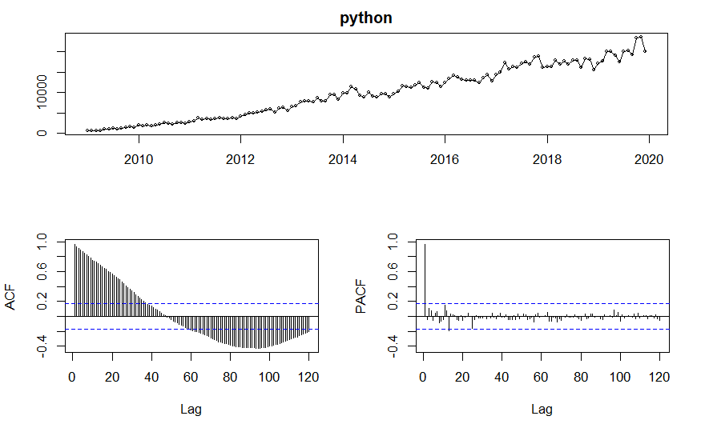

```r
tsdisplay(python, lag.max = 120)
```

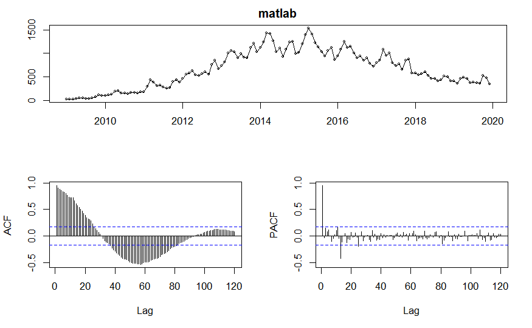

```r
tsdisplay(matlab, lag.max = 120)
```

## Box Cox

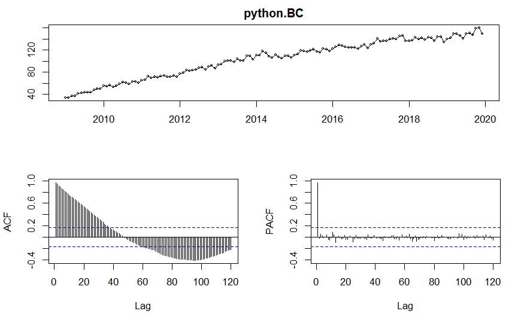

```r
python.BC.lambda <- BoxCox.lambda(python)
matlab.BC.lambda <- BoxCox.lambda(matlab)
python.BC <- BoxCox(python, lambda = python.BC.lambda)
matlab.BC <- BoxCox(matlab, lambda = matlab.BC.lambda)
tsdisplay(python.BC, lag.max = 120)
```

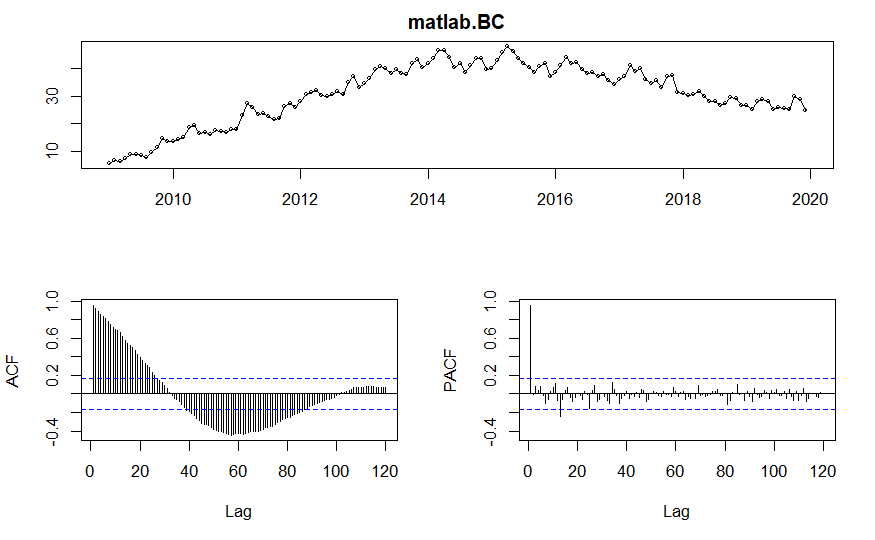

```r
tsdisplay(matlab.BC, lag.max = 120)
```

## Differentiating (lag = 1)

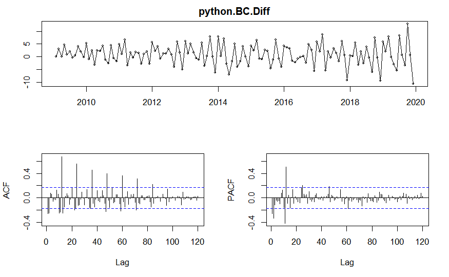

```r
python.BC.Diff <- diff(python.BC, lag = 1)
matlab.BC.Diff <- diff(matlab.BC, lag = 1)
tsdisplay(python.BC.Diff, lag.max = 120)
```

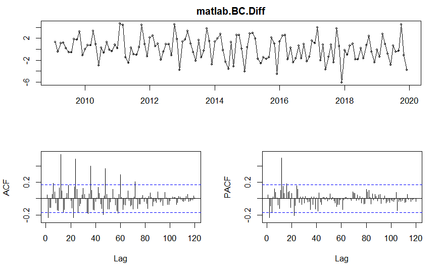

```r
tsdisplay(matlab.BC.Diff, lag.max = 120)
```

## Autocorrelation

Po dokonaniu powyższych przekształceń, z wykresu autokorelacji widzimy, że w szereg czasowy posiada sezonowość, której nie było widać na początku. Rysujemy większy wykres autokorelacji, żeby wyznaczyć sezonowość szeregu.

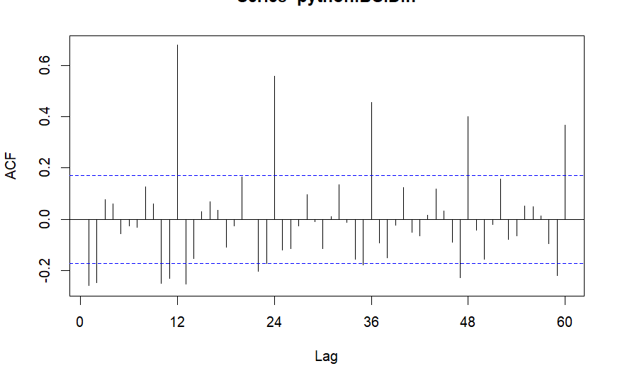

```r
Acf(python.BC.Diff, lag.max = 60)
```

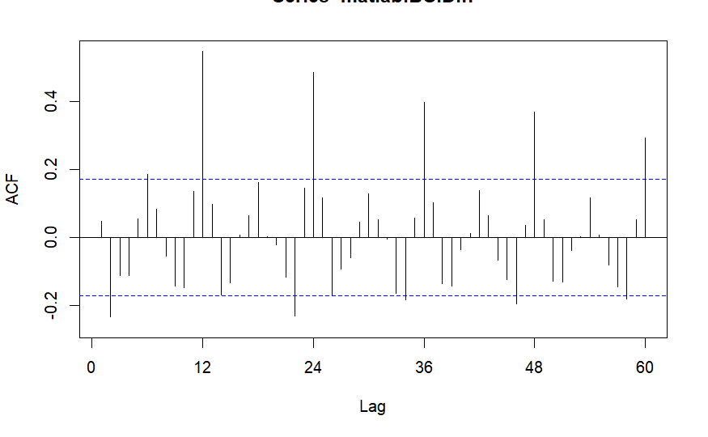

```r
Acf(matlab.BC.Diff, lag.max = 60)
```

## Seasonality

Z poprzednigo wykresu autokorelacji wiemy, że występuje roczna sezonowość. Zbadajmy tą sezonowość i spróbujmy zrozumieć skąd ona pochodzi.

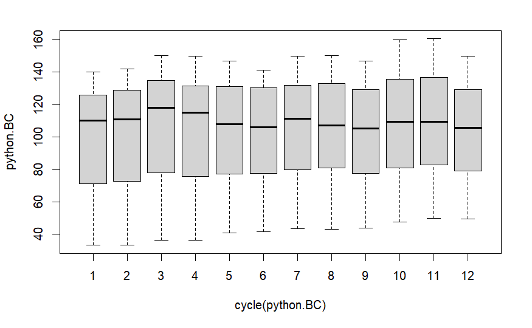

```r
boxplot(python.BC ~ cycle(python.BC))
```

Z wykresu słupkowego widzimy małe zwiększenie średniej popularności języka `Python` w marcu, lipcu i październiku. Zobaczmy jak wygląda ta sezonowość po usunięciu trendu.

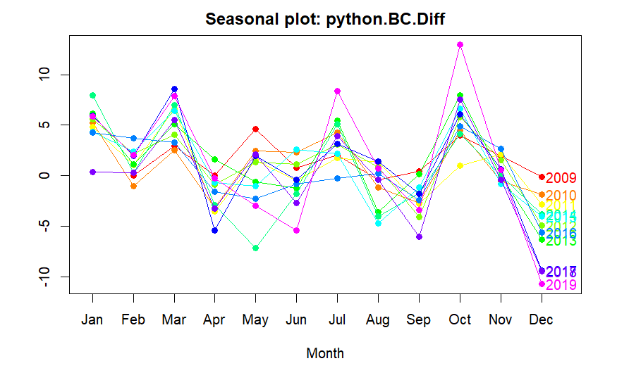

```r
seasonplot(python.BC.Diff, col=rainbow(12), year.labels=TRUE, pch=19)
```

Znowu widzimy zwiększenie popularności języka `Python` w tych samych miesiącach. Sprawdźmy, czy występuje taka sama sezonowość dla języka `Matlab`.

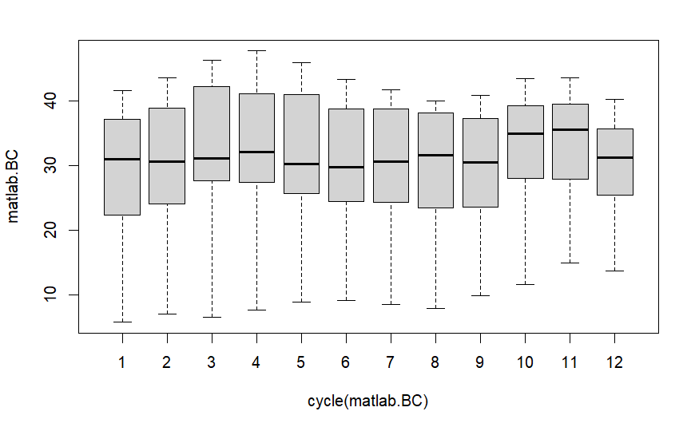

```r
boxplot(matlab.BC ~ cycle(matlab.BC))
```

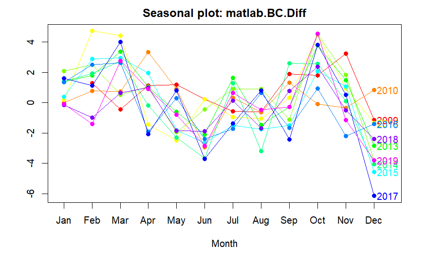

```r
seasonplot(matlab.BC.Diff, col=rainbow(12), year.labels=TRUE, pch=19)
```

Okazuje się, że sytuacja jest podobna, aczkolwiek nie identyczna: dla języka `Matlab` nie jest tak widocznym wzrost popularności w lipcu, w porównaniu do języka `Python`.

Przypuszczam, że taka sezonowość jest spowodowana studentami: zwykle w Europie i Amerykach semestry zaczynają się w październiku i marcu, dlatego studenci tworzą więcej pytań właśnie w tych miesiącach. Natomiast w lipcu zwykle zaczynają się wakacji i niktóre studenci zaczynają uczyć się tych przedmiotów, które ich interesują. Ponieważ wcześniej już stwierdziliśmy, że `Matlab` jest o wiele mniej popularny niz `Python`, to powyższe przypuszczenie łatwo wyjaśnia dlaczego `Matlab` ma mniej widoczny wzrost popularności w lipcu, nieżeli `Python`.

## Differentiating (lag = 12)

Wracając do przekształcenia szeregu czasowego do postaci stacjonarnej, używamy różnicowania z opóźnieniem 12 aby pozbyć się sezonowości.

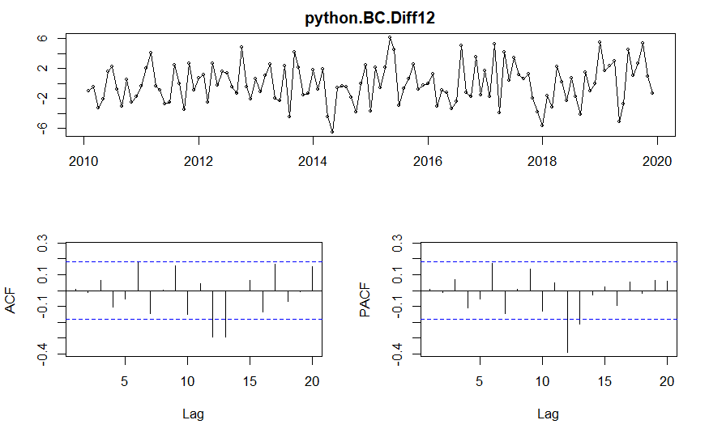

```r
python.BC.Diff12 <- diff(python.BC.Diff, lag = 12)
matlab.BC.Diff12 <- diff(matlab.BC.Diff, lag = 12)
tsdisplay(python.BC.Diff12, lag.max = 20)
```

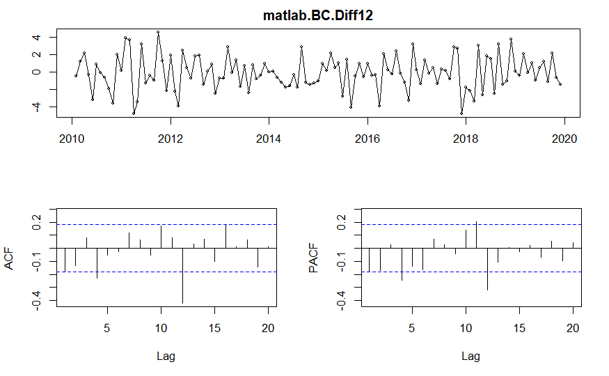

```r
tsdisplay(matlab.BC.Diff12, lag.max = 20)
```

## Autocorrelation and partial autocorrelation

Z powyższych wykresów widzimy, że otrzymalismy szereg stacjonarny.

Za pomocą wykresów autokorelacji wyznaczmy rząd modelu ruchomej średniej. Dla szeregu języka `Matlab` wynosi on 12, natomiast dla szeregu języka `Python` pasują rzędy 12 i 13. Wybieramy model rzędu 12 ponieważ jest on mniej skomplikowany oraz posiada sensowne uzasadnienie - sezonowość roczna.

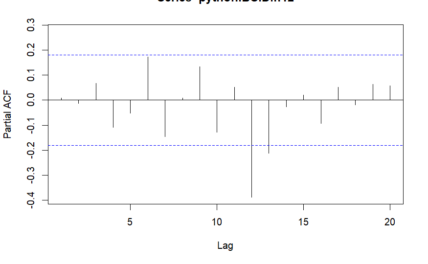

```r
Pacf(python.BC.Diff12, lag.max = 20)
```

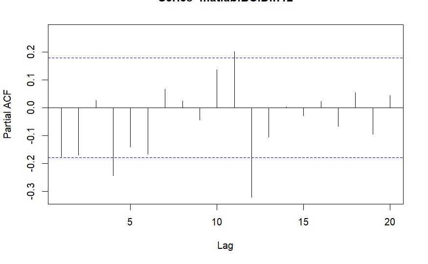

```r
Pacf(matlab.BC.Diff12, lag.max = 20)
```

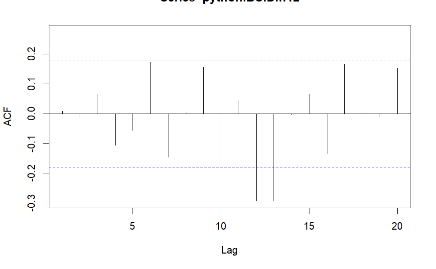

```r
Acf(python.BC.Diff12, lag.max = 20)
```

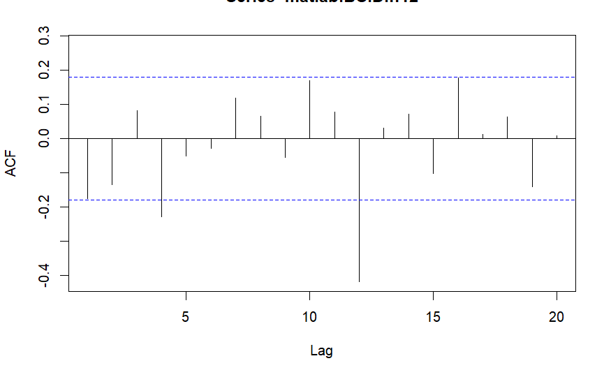

```r
Acf(matlab.BC.Diff12, lag.max = 20)
```

## Autoregression model and forecasting (Python)

Tworzymy model autoregresji rzędu 12. Dokonujemy transformacji odwrotnych szeregu stacjonarnego w celu otrzymania szeregu identycznego z pierwotnym. Rysujemy łącznie wykres wartości znanych oraz wartości przewidzianych.

Otrzymana prognoza twierdzi, że popularność języka `Python` będzie zwiększać się w kolejnych latach.

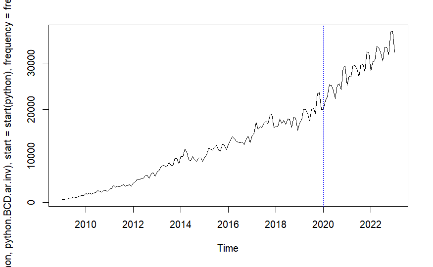

```r
python.BCD.ar <- ar(python.BC.Diff12, order = 12)
python.BCD.ar.inv <- diffinv(forecast(python.BCD.ar, h = 24)$mean,
                             differences=1,
                             lag=12,
                             xi=python.BC.Diff[(length(python.BC.Diff)-11):length(python.BC.Diff)])
python.BCD.ar.inv <- diffinv(python.BCD.ar.inv,
                             differences=1,
                             lag=1,
                             xi=python.BC[length(python.BC)])
python.BCD.ar.inv <- InvBoxCox(python.BCD.ar.inv, lambda = python.BC.lambda)
plot(ts(c(python, python.BCD.ar.inv), start = start(python), frequency = frequency(python)))
abline(v = end(python.BC.Diff12)[1] + end(python.BC.Diff12)[2] / 12, col = "blue", lty = 3)
```

## Simple moving average forecasting (Python)

Przewidujemy podalszy rozwój języka `Python` za pomocą modelu ruchomej średniej rżedu 12. W tym przypadku również otrzymujemy prognozę o zwiększeniu popularności języka `Python`.

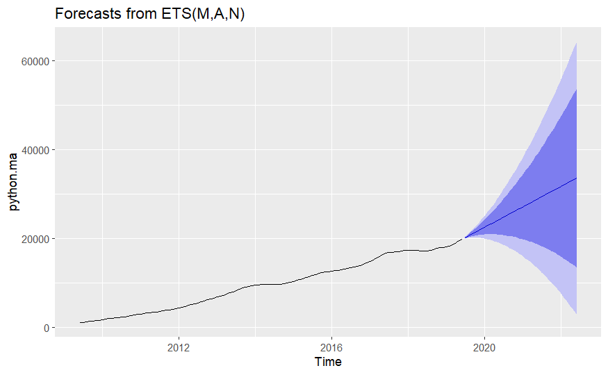

```r
python.ma <- ma(python, order = 12, centre = FALSE)
autoplot(forecast(python.ma, h = 36))
```

## Autoregression model and forecasting (Matlab)

Przeprowadzamy analogiczne działania dla drugiego szeregu czasowego. Tym razem prognoza twierdzi, że popularność języka `Matlab` będzie zmniejszać się w kolejnych latach. i

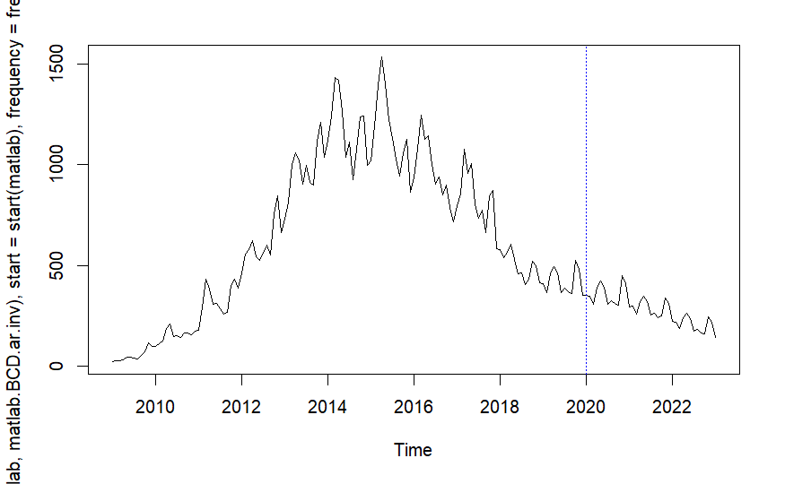

```r
matlab.BCD.ar <- ar(matlab.BC.Diff12, order = 12)
matlab.BCD.ar.inv <- diffinv(forecast(matlab.BCD.ar, h = 24)$mean,
                             differences=1,
                             lag=12,
                             xi=matlab.BC.Diff[(length(matlab.BC.Diff)-11):length(matlab.BC.Diff)])
matlab.BCD.ar.inv <- diffinv(matlab.BCD.ar.inv,
                             differences=1,
                             lag=1,
                             xi=matlab.BC[length(matlab.BC)])
matlab.BCD.ar.inv <- InvBoxCox(matlab.BCD.ar.inv, lambda = matlab.BC.lambda)
plot(ts(c(matlab, matlab.BCD.ar.inv), start = start(matlab), frequency = frequency(matlab)))
abline(v = end(matlab.BC.Diff12)[1] + end(matlab.BC.Diff12)[2] / 12, col = "blue", lty = 3)
```

## Simple moving average forecasting (Matlab)

Analogiczną prognozę otzymujemy używając modelu ruchmej średniej.

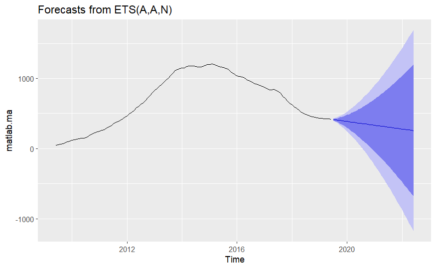

```r
matlab.ma <- ma(matlab, order = 12, centre = FALSE)
autoplot(forecast(matlab.ma, h = 36))
```